# BUDA 535 Final

Jordon Wolfram +Ivonne Wardell + Scott Branham

April 28, 2018

## Purpose

This is the Spring 2018 Group Final Project for BUDA 535. This final consists of 4 questions and is worth 100 points. This final is expected to be done in teams.

This document presents the third and fourth questions.

### Problem 3 (30 Points)

*Throughout the homework in this course you have analyzed a data set to predict the knowledge of employees at a company based on a survey and questionnaire. You have been asked to use different methods on this data, but now it is time to formalize the results. Present a concise write up where you describe the method of how you define knowledge (you may define it anyway you choose but please defend it), and the best prediction model you have found for it. Describe any limitations of your model, and what you think a “good” prediction is. You can mention the methods you have tried and include them in the .Rmd file, but do not show them when it knits. To do this use the `include=FALSE` argument in the chunk heading. Look at this .Rmd below for an example. Note, you may change what you did in your homework if you feel it will result in a better analysis!*

We were given a file that contains the results of a questionare that was given to 156 employees at a major company. Two experts sat in a room asked each employee to define a process or a term, then gave a score of 1 to 5. These processes were also categorized as questions that would be considered technical for a field versus common questions that everyone should know.

```r
QDat<- read.csv("C:\\Users\\Jordon Wolfram\\Documents\\WVU\\BUDA 535 Data Mining\\buda535_q_data.csv")
names(QDat[,3:26])
```

```
##  [1] "sex"             "age"             "CloseFriendsG1"
##  [4] "CloseFriendsG2"  "CloseFriendsG3"  "CloseFriendsG4"
##  [7] "CloseFriendsG5"  "CloseFriendsG6"  "NumberFriendsG1"
## [10] "intl"            "vocal"           "classical"
## [13] "folk"            "rock"            "country"
## [16] "pop"             "alternative"     "hiphop"
## [19] "unclassifiable"  "Pop1"            "Pop2"
## [22] "Pop3"            "Pop4"            "Pop5"
```

Our goal as data analyists was to gain an understanding of this employee data and provide insights into their level of “Knowledge”. In the steps below, we first summarize the question data into an overall score. This provides insight into which employees ranked highest on the question scores. Being that the questions were divided into Technical vs Common scores though, we want to define knowledge further into quadrants:

We chose this method because it can highlight not only the employees with a high overall score, but also those who have a high technical knowledge. While we do not understand the full intention that the compny has for this data, we believe that this can help in the decision-making process for what employees are potentially the most valuable and also what positions employees are most qualified for. The method for this selection is below:

```r
#Trim down to just the question data
QDat2<-QDat[,-(1:26)]

#Sum all of the questions per employee into a overall score
over_score<-apply(QDat2,1,sum)

#Scale the data
QDat3<-apply(QDat2,2,scale)
m1<-prcomp(QDat3)
sum(m1$rotation[,1]<=0)
```

```
## [1] 1
```

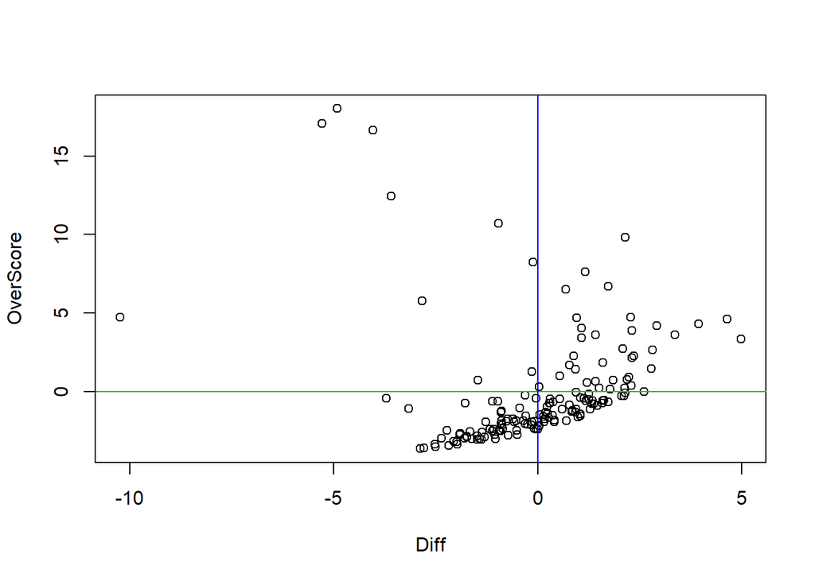

```r
#Create and View the Quadrants
OverScore=QDat3%*%m1$rotation[,1]
Diff=QDat3%*%m1$rotation[,2]
plot(OverScore~Diff)
abline(h=0,col=3)
abline(v=0,col=4)
```

```r
#Create a new variable "classification" for the quadrants
QDat$classification<-rep("low_tech_low_over",dim(QDat)[1])             #Employees with low (negative) difference in their technical vs common score AND low overall score
QDat$classification[OverScore<=0 & Diff>=0]="low_tech_high_over"       #Employees with low (negative) difference in their technical vs common score AND high overall score
QDat$classification[OverScore>0 & Diff>=0]="high_tech_high_over"       #Employees with high difference in their technical vs common score AND high overall score
QDat$classification[OverScore>0 & Diff<0]="high_tech_low_over"         #Employees with high difference in their technical vs common score AND low overall score

#Add bank in the data demographics
QDatClass<-cbind(QDat[,(3:26)],QDat$classification)
names(QDatClass)[25]="classification"

#Verify that four classifications were made
unique(QDatClass$classification)
```

```
## [1] low_tech_low_over   low_tech_high_over  high_tech_high_over
## [4] high_tech_low_over
## 4 Levels: high_tech_high_over high_tech_low_over ... low_tech_low_over
```

Classifying an employee’s knowledge is an important step. We wanted to take it further though and start digging into the demographic data that was provided for each employee and see what insights this contained into what classification quadrant they would fall into. Before doing that, we want to look at a summary breakdown of the classifications to give us a starting point.

```r
table(QDatClass$classification)
```

```
##
## high_tech_high_over  high_tech_low_over  low_tech_high_over
##                  35                  10                  48
##   low_tech_low_over
##                  63
```

```r
#PAccuracy that you would get by simply choosing the most common classification of low_tech_low_over.
max(table(QDatClass$classification))/nrow(QDatClass)
```

```
## [1] 0.4038462
```

So if we were to not consider demographic information and simply classify all employees as low_tech_low_over, we would be right 40% of the time. Important too, we would miss the benefit of identifying the other three classifications which can help with employee insight and placement.

By looking at the demographic data surrounding each employee, we hope to improve on this 40% and to help classify what classification an employee falls into and what are the most important demographics that create this.

A lot of different models and methods were run on the data. We found that while it is simplistic, the recursive partitioning method created an ideal model for predicting the classification of an employee. The code is below:

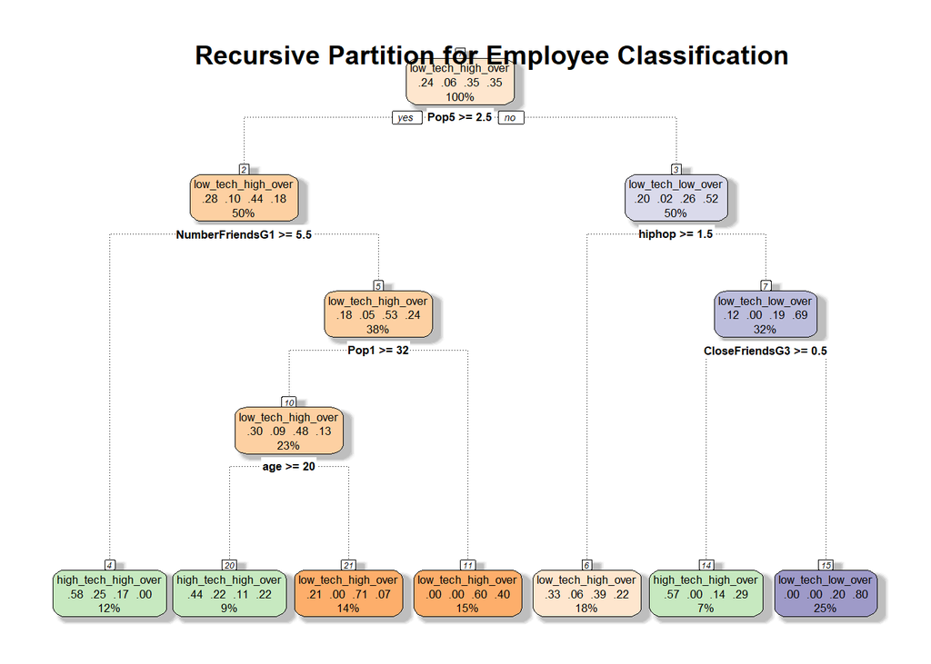

```r
#Select 56 of the 156 observations to be the test data and use the remaining 100 observations as the training data.
set.seed(2018)
Samp1<-sample(1:156,56)

#Run the Rpart model
r1 <- rpart(classification ~ .,QDatClass[-Samp1,], method="class")

#Visualize the tree
fancyRpartPlot(r1, main = "Recursive Partition for Employee Classification", sub = "")
```

This tree plot breaks down the most important partitions and pathways in determining employee classification. Next, let’s look at how this improved on the original accuracy.

```r
preds1=predict(r1,newdata=QDatClass[Samp1,],type="class")
Res1 <-table(preds1,QDatClass$classification[Samp1])
Res1
```

```
##
## preds1                high_tech_high_over high_tech_low_over
##   high_tech_high_over                   1                  1
##   high_tech_low_over                    0                  0
##   low_tech_high_over                    9                  2
##   low_tech_low_over                     1                  1
##
## preds1                low_tech_high_over low_tech_low_over
##   high_tech_high_over                  1                 1
##   high_tech_low_over                   0                 0
##   low_tech_high_over                   9                 9
##   low_tech_low_over                    3                18
```

```r
#Prediction Error
1-((sum(Res1)-sum(diag(Res1)))/length(Samp1))
```

```
## [1] 0.5
```

We were able to improve the accuracy and bring it up to 50%. While this is far from perfection, it shows some good trends. By analyzing the data, we not only created these classification quandrants that apply to current employees, we also accessed what demographics can affect that.

Again, it can’t be stated enough that many models and methods were run on this data and so there are comparative models and data that can be provided via .rmd for those that would like to dig into the analysis further.

Other models such as glmnet confirm that the most important demographic factors in the chart above have a high emphasis in other models as well. For instance:

Elastic Net Model

Here we can see the coefficients hfrom each demographic factor that influence the each classification the most. This is useful information if you are looking to target one of the four classified groups of employees.

```r
#Coefients that show how much the demographics influence the model.
coef(Mod)
```

```
## $high_tech_high_over
## 25 x 1 sparse Matrix of class "dgCMatrix"
##                           s0
##                 -0.489401279
## sex              .
## age              .
## CloseFriendsG1   .
## CloseFriendsG2   .
## CloseFriendsG3   .
## CloseFriendsG4   .
## CloseFriendsG5   0.316610305
## CloseFriendsG6   .
## NumberFriendsG1  0.011687147
## intl             .
## vocal            .
## classical        .
## folk             .
## rock            -0.011923733
## country          .
## pop              0.046192661
## alternative      .
## hiphop           0.002964563
## unclassifiable   .
## Pop1             .
## Pop2             .
## Pop3             .
## Pop4             .
## Pop5             .
##
## $high_tech_low_over
## 25 x 1 sparse Matrix of class "dgCMatrix"
##                          s0
##                 -2.03938147
## sex              .
## age              .
## CloseFriendsG1   .
## CloseFriendsG2   0.03112962
## CloseFriendsG3   .
## CloseFriendsG4   .
## CloseFriendsG5   .
```

[output cut: 60 more lines]

```
## intl             .
## vocal            .
## classical        .
## folk             0.24096180
## rock             .
## country          .
## pop              .
## alternative      .
## hiphop           .
## unclassifiable   .
## Pop1             .
## Pop2            -0.21213773
## Pop3            -0.21003809
## Pop4            -0.05502391
## Pop5            -0.21888694
```

This information could be applied during the hiring process of new employees to see the likelyhood of what classification they would fall into. Therefore, if the company is looking to higher an employee that it likely to fall into the high_tech_high_over class of knowledge, they can target the demographics that apply.

### Problem 4 (30 Points)

*For this problem we will use the `MinnLand` data in the `alr4` package. I want to predict a categorical response on whether the `acreprice` is above or below the mean. The data set we will use for this problem is as follows:*

*The code creates a `class` variable in the `ML` data set that defines whether the `acreprice` is above or below the mean. It also removes all `NA`’s from the data, and then removes `acreprice`. I’ve removed this to make modeling easier, as you do not want it for these methods. All other variables in this data set are fair to use.*

*Build a predictive model using the `ML` data where your response is class. Give any insights you can on the models you built, while only presenting the model you consider the best. Treat the set `test` as a validation set for this model to compare final predictions on. Discuss any results that you may find interesting about what variables are drivers and how they effect the prediction. Discuss any disadvantages your model may have over other you fit, while justifying why you chose it. Just as in problem 3 include your code for all models you build, but do not present the results unless they are relevant. It is OK to explain your process in your text without printing the code, just make sure the code is in the .Rmd. HINT: An interesting result may be to look at the misclassified points and comment on the value of these properties, does your model over or undervalue based on the predictions.*

```r
#install.packages("alr4")
library(alr4)
data("MinnLand")
ML<-na.omit(MinnLand)
ML$class<-rep("Above",dim(ML)[1])
ML$class[which(ML$acrePrice<=mean(ML$acrePrice))]="Below"
names(ML)
```

```
##  [1] "acrePrice"    "region"       "improvements" "year"
##  [5] "acres"        "tillable"     "financing"    "crpPct"
##  [9] "productivity" "class"
```

```r
ML=ML[,-1]
ML$class=as.factor(ML$class)
names(ML)
```

```
## [1] "region"       "improvements" "year"         "acres"
## [5] "tillable"     "financing"    "crpPct"       "productivity"
## [9] "class"
```

```r
table(ML$class)
```

```
##
## Above Below
##  3710  5060
```

```r
set.seed(616)
test<-sample(1:8770,2770)
train <- (1:8770)[-test]
```

OUr group started by getting an overview of the whole dataset to understand the range of each variable.

```r
summary(ML)
```

```
##            region      improvements         year          acres
##  Northwest    : 787   Min.   : 0.000   Min.   :2002   Min.   :   1.0
##  West Central :1744   1st Qu.: 0.000   1st Qu.:2005   1st Qu.:  65.0
##  Central      :1058   Median : 0.000   Median :2007   Median :  80.0
##  South West   :2436   Mean   : 2.292   Mean   :2007   Mean   : 114.8
##  South Central:1972   3rd Qu.: 0.000   3rd Qu.:2008   3rd Qu.: 155.0
##  South East   : 773   Max.   :83.000   Max.   :2011   Max.   :1365.0
##     tillable                financing        crpPct         productivity
##  Min.   :  5.00   title_transfer :7849   Min.   :  0.000   Min.   : 1.00
##  1st Qu.: 87.00   seller_financed: 921   1st Qu.:  0.000   1st Qu.:60.00
##  Median : 94.00                          Median :  0.000   Median :68.00
##  Mean   : 88.18                          Mean   :  2.919   Mean   :66.74
##  3rd Qu.: 97.00                          3rd Qu.:  0.000   3rd Qu.:76.00
##  Max.   :100.00                          Max.   :100.000   Max.   :99.00
##    class
##  Above:3710
##  Below:5060
##
##
##
##
```

```r
str(ML)
```

```
## 'data.frame':    8770 obs. of  9 variables:
##  $ region      : Factor w/ 6 levels "Northwest","West Central",..: 1 1 1 1 1 1 1 1 1 1 ...
##  $ improvements: num  0 0 0 0 0 0 41 0 0 6 ...
##  $ year        : num  2006 2007 2007 2006 2007 ...
##  $ acres       : int  160 160 160 82 189 40 80 155 120 118 ...
##  $ tillable    : num  96 96 97 65 81 45 28 96 21 69 ...
##  $ financing   : Factor w/ 2 levels "title_transfer",..: 1 1 1 1 1 1 1 1 1 1 ...
##  $ crpPct      : num  0 0 0 0 0 0 0 0 0 0 ...
##  $ productivity: int  60 65 63 58 33 59 55 64 25 44 ...
##  $ class       : Factor w/ 2 levels "Above","Below": 2 2 2 2 2 2 2 2 2 2 ...
```

```r
dim(ML)
```

```
## [1] 8770    9
```

After spending time reviewing and understanding the data, we worked through many models that were designed to predict most accurately whether the acre price would be above or below the mean sale price. Classification tree models and R-part models were developed to review the overall impact of the class variable. They did provide initial clarification that the mean sale prices were accurately depicted, additional understanding was needed to confirm this. Through extensive testing, we decided to utilize the GLM model using the caret package tools to make the best determination.

# Using Caret to generate a GLM model.

```r
fitControl <- trainControl(method = "cv",
                           number = 10)
```

```r
#Create the model that will self-select the best alpha and lamba tuning parameters using the training data
m1<-train(class~.,data=ML[train,],method="glmnet",trControl=fitControl,family="binomial")

#Run the predictions on the test data
preds<-predict(m1,newdata = ML[-train,])
confusionMatrix(data=preds, reference =ML[-train,]$class)
```

```
## Confusion Matrix and Statistics
##
##           Reference
## Prediction Above Below
##      Above   967   207
##      Below   199  1397
##
##                Accuracy : 0.8534
##                  95% CI : (0.8397, 0.8664)
##     No Information Rate : 0.5791
##     P-Value [Acc > NIR] : <2e-16
##
##                   Kappa : 0.6996
##  Mcnemar's Test P-Value : 0.7283
##
##             Sensitivity : 0.8293
##             Specificity : 0.8709
##          Pos Pred Value : 0.8237
##          Neg Pred Value : 0.8753
##              Prevalence : 0.4209
##          Detection Rate : 0.3491
##    Detection Prevalence : 0.4238
##       Balanced Accuracy : 0.8501
##
##        'Positive' Class : Above
##
```

With this honed in model, we were able to achieve an 85% prediction accuracy on the test data. Now we can look at how each coefficient affected the model

```r
coef(m1$finalModel, m1$bestTune$lambda)
```

```
## 13 x 1 sparse Matrix of class "dgCMatrix"
##                                      1
## (Intercept)               1.737589e+03
## regionWest Central       -2.693449e+00
## regionCentral            -4.697755e+00
## regionSouth West         -3.607691e+00
## regionSouth Central      -4.612863e+00
## regionSouth East         -4.890280e+00
## improvements             -9.423970e-02
## year                     -8.605468e-01
## acres                     1.349603e-03
## tillable                 -2.823258e-02
## financingseller_financed  3.596520e-01
## crpPct                    4.527637e-02
## productivity             -6.058498e-02
```